# Predicting the severity of car accidents and the factors that influence them

### 5055 - Data Processing 2: Scalable Data Processing, Legal & Ethical Foundations of Data Science

### Team K - Erik Baričević, Michael Ladaa, Alex Schmid

This project is about predicting the severity of car accidents and the factors such as weather conditions or accident location that influence it. We used three models (Linear Regression, Logistic Regression and Random Forest) to predict accident severity (1,2,3,4) and compared them. As input, we used a dataset from Kaggle provided by Sobhan Moosavi, who collects the data using several APIs. The dataset consists of about 7.7 million records of car accidents recorded between 2016 and 2023 in the United States. Each dataset consists of accident severity (1,2,3,4) with 1 being the least impactful and 4 being the most impactful. In addition to the accident severity, there is the ID, date, location of the accident and natural factors that were present during the accident, such as weather conditions, temperature and visibility.

https://www.kaggle.com/datasets/sobhanmoosavi/us-accidents

The following code can be divided into four parts:

```
1. Import Modules
2. Setup Spark
3. Pre-Processing
4. Data Analysis
```

## 1. Import Modules

Here we have imported all the necessary modules.

```python
# Import the findspark module
import findspark

# Import the SparkSession module
from pyspark.sql import SparkSession

# Import pyspark sql function and data types
from pyspark.sql import Row
from pyspark.sql.types import *
from pyspark.sql.functions import *
from pyspark.sql.functions import col, when
from pyspark.sql.types import BooleanType

# Import the modules for creating the plots
import matplotlib.pyplot as plt
import seaborn as sns
import pandas as pd
```

## 2. Setup Spark

Here we load Spark by indicating the path where it is installed.

```python
# Initialize via the full spark path
findspark.init("/usr/local/spark/")
```

Here we create a new Spark session with the appropriate parameters that you can see below if there is not already one.

```python
# Build the SparkSession
spark = SparkSession.builder \
   .master("local") \
   .appName("Linear Regression Model") \
   .config("spark.executor.memory", "5gb") \
   .getOrCreate()
```

Here we define the main entry point for using Spark functionalities.

```python
# Main entry point for Spark functionality. A SparkContext represents the
# connection to a Spark cluster, and can be used to create :class:`RDD` and
# broadcast variables on that cluster.
sc = spark.sparkContext
```

## 3. Pre-Processing

Here we load our dataset into the RDD "data", then we take the first line, which is the header, and store it in the string "header", then we convert the header into an RDD and at the end we subtract the header from the dataset. So we have two RDDs, one with the header and one with the rows. After this step, we just check the header and the first five rows of the dataset as they look.

```python
data = sc.textFile('./US_Accidents_March23.csv')

# Return the first element in this RDD.
header = data.first()

# Distribute a local Python collection to form an RDD. "header" above is not an RDD it's a variable. With sc.parallelize() you can transform it into a RDD.
header = sc.parallelize([header])

# Return each value in `self` that is not contained in `other`
lines = data.subtract(header)
```

```python
header.collect()
```

```
['ID,Source,Severity,Start_Time,End_Time,Start_Lat,Start_Lng,End_Lat,End_Lng,Distance(mi),Description,Street,City,County,State,Zipcode,Country,Timezone,Airport_Code,Weather_Timestamp,Temperature(F),Wind_Chill(F),Humidity(%),Pressure(in),Visibility(mi),Wind_Direction,Wind_Speed(mph),Precipitation(in)…
```

```python
lines.take(5)
```

```
['A-66,Source2,3,2016-02-09 08:23:36,2016-02-09 08:53:36,39.622787,-84.229858,,,0.01,Accident on I-75 Southbound at I-675. Expect delays.,I-75 N,Miamisburg,Montgomery,OH,45342,US,US/Eastern,KMGY,2016-02-09 08:14:00,21.0,10.6,81.0,29.7,1.2,WSW,9.2,0.0,Light Snow,False,False,False,False,False,False,Fa…
 'A-147,Source2,2,2016-02-15 07:15:56,2016-02-15 07:45:56,39.831444,-84.097267,,,0.0,Lane blocked due to accident on Heritage Park Blvd at Greeley Ave.,Greeley Ave,Dayton,Montgomery,OH,45424-1794,US,US/Eastern,KFFO,2016-02-15 06:58:00,24.1,17.0,98.0,30.04,1.5,SSE,5.8,0.0,Light Snow,False,False,False…
 'A-166,Source2,3,2016-02-15 19:37:18,2016-02-15 20:22:18,39.824703,-83.141228,,,0.01,Right lane blocked due to accident on I-71 Northbound at Exit 94 US-62 Harrisburg Pike. Approach with care.,I-71 N,Orient,Franklin,OH,43146,US,US/Eastern,KTZR,2016-02-15 19:35:00,32.9,,100.0,29.86,1.8,Calm,,,Overca…
 'A-288,Source2,2,2016-02-19 08:32:47,2016-02-19 09:02:47,39.800312,-84.218811,,,0.0,Accident on Redwood Ave at OH-48 Main St. Expect delays.,N Main St,Dayton,Montgomery,OH,45405-5105,US,US/Eastern,KDAY,2016-02-19 08:56:00,48.0,,52.0,30.03,10.0,South,27.6,,Overcast,False,False,False,False,False,Fals…
 'A-438,Source2,2,2016-03-01 12:50:36,2016-03-01 13:20:36,39.591389,-84.229485,,,0.01,Accident on OH-741 Springboro Pike near Tech Blvd.,Springboro Pike,Miamisburg,Montgomery,OH,45342-4940,US,US/Eastern,KMGY,2016-03-01 12:53:00,48.0,,71.0,29.72,10.0,WNW,8.1,0.02,Light Rain,False,False,True,False,Fal…
```

Here we split our lines by using the map function to apply the lambda function to all the elements and separate them at ",".

```python
lines = lines.map(lambda line: line.split(","))

lines.take(2)
```

```
[['A-66',
  'Source2',
  '3',
  '2016-02-09 08:23:36',
  '2016-02-09 08:53:36',
  '39.622787',
  '-84.229858',
  '',
  '',
  '0.01',
  'Accident on I-75 Southbound at I-675. Expect delays.',
  'I-75 N',
  'Miamisburg',
  'Montgomery',
  'OH',
  '45342',
  'US',
  'US/Eastern',
  'KMGY',
  '2016-02-09 08:14:00',
  '21.0',
  '10.6',
  '81.0',
  '29.7',
  '1.2',
  'WSW',
  '9.2',
  '0.0',
  'Light Snow',
  'False',
  'False',
  'False',
  'False',
  'False',
  'False',
  'False',
  'False',
  'False',
  'False',
  'False',
```

[output cut: 37 more lines]

```
  'False',
  'False',
  'False',
  'False',
  'False',
  'False',
  'False',
  'False',
  'False',
  'False',
  'False',
  'Night',
  'Day',
  'Day',
  'Day']]
```

Here we use the map function to convert RDD into a data frame.

```python
df = lines.map(lambda line: Row(ID=line[0],
                              Source=line[1],
                              Severity=line[2],
                              Start_Time=line[3],
                              End_Time=line[4],
                              Start_Lat=line[5],
                              Start_Lng=line[6],
                              End_Lat=line[7],
                              End_Lng=line[8],
                              Distance_mi=line[9],
                              Description=line[10],
                              Street=line[11],
                              City=line[12],
                              County=line[13],
                              State=line[14],
                              Zipcode=line[15],
                              Country=line[16],
                              Timezone=line[17],
                              Airport_Code=line[18],
                              Weather_Timestamp=line[19],
                              Temperature_F=line[20],
                              Wind_Chill_F=line[21],
                              Humidity=line[22],
                              Pressure_in=line[23],
                              Visibility_mi=line[24],
                              Wind_Direction=line[25],
                              Wind_Speed_mph=line[26],
                              Precipitation_in=line[27],
                              Weather_Condition=line[28],
                              Amenity=line[29],
                              Bump=line[30],
                              Crossing=line[31],
                              Give_Way=line[32],
                              Junction=line[33],
                              No_Exit=line[34],
                              Railway=line[35],
                              Roundabout=line[36],
                              Station=line[37],
                              Stop=line[38],
                              Traffic_Calming=line[39],
                              Traffic_Signal=line[40],
                              Turning_Loop=line[41],
                              Sunrise_Sunset=line[42],
                              Civil_Twilight=line[43],
                              Nautical_Twilight=line[44],
                              Astronomical_Twilight=line[45])).toDF()

df.show(5)
```

```
+-----+-------+--------+-------------------+-------------------+---------+----------+-------+-------+-----------+--------------------+---------------+----------+----------+-----+----------+-------+----------+------------+-------------------+-------------+------------+--------+-----------+-----------…
|   ID| Source|Severity|         Start_Time|           End_Time|Start_Lat| Start_Lng|End_Lat|End_Lng|Distance_mi|         Description|         Street|      City|    County|State|   Zipcode|Country|  Timezone|Airport_Code|  Weather_Timestamp|Temperature_F|Wind_Chill_F|Humidity|Pressure_in|Visibility_…
+-----+-------+--------+-------------------+-------------------+---------+----------+-------+-------+-----------+--------------------+---------------+----------+----------+-----+----------+-------+----------+------------+-------------------+-------------+------------+--------+-----------+-----------…
| A-66|Source2|       3|2016-02-09 08:23:36|2016-02-09 08:53:36|39.622787|-84.229858|       |       |       0.01|Accident on I-75 ...|         I-75 N|Miamisburg|Montgomery|   OH|     45342|     US|US/Eastern|        KMGY|2016-02-09 08:14:00|         21.0|        10.6|    81.0|       29.7|          1…
|A-147|Source2|       2|2016-02-15 07:15:56|2016-02-15 07:45:56|39.831444|-84.097267|       |       |        0.0|Lane blocked due ...|    Greeley Ave|    Dayton|Montgomery|   OH|45424-1794|     US|US/Eastern|        KFFO|2016-02-15 06:58:00|         24.1|        17.0|    98.0|      30.04|          1…
|A-166|Source2|       3|2016-02-15 19:37:18|2016-02-15 20:22:18|39.824703|-83.141228|       |       |       0.01|Right lane blocke...|         I-71 N|    Orient|  Franklin|   OH|     43146|     US|US/Eastern|        KTZR|2016-02-15 19:35:00|         32.9|            |   100.0|      29.86|          1…
|A-288|Source2|       2|2016-02-19 08:32:47|2016-02-19 09:02:47|39.800312|-84.218811|       |       |        0.0|Accident on Redwo...|      N Main St|    Dayton|Montgomery|   OH|45405-5105|     US|US/Eastern|        KDAY|2016-02-19 08:56:00|         48.0|            |    52.0|      30.03|         10…
|A-438|Source2|       2|2016-03-01 12:50:36|2016-03-01 13:20:36|39.591389|-84.229485|       |       |       0.01|Accident on OH-74...|Springboro Pike|Miamisburg|Montgomery|   OH|45342-4940|     US|US/Eastern|        KMGY|2016-03-01 12:53:00|         48.0|            |    71.0|      29.72|         10…
+-----+-------+--------+-------------------+-------------------+---------+----------+-------+-------+-----------+--------------------+---------------+----------+----------+-----+----------+-------+----------+------------+-------------------+-------------+------------+--------+-----------+-----------…
only showing top 5 rows
```

With the two following functions we can check the datatypes of our columns.

```python
df.dtypes
```

```
[('ID', 'string'),
 ('Source', 'string'),
 ('Severity', 'string'),
 ('Start_Time', 'string'),
 ('End_Time', 'string'),
 ('Start_Lat', 'string'),
 ('Start_Lng', 'string'),
 ('End_Lat', 'string'),
 ('End_Lng', 'string'),
 ('Distance_mi', 'string'),
 ('Description', 'string'),
 ('Street', 'string'),
 ('City', 'string'),
 ('County', 'string'),
 ('State', 'string'),
 ('Zipcode', 'string'),
 ('Country', 'string'),
 ('Timezone', 'string'),
 ('Airport_Code', 'string'),
 ('Weather_Timestamp', 'string'),
 ('Temperature_F', 'string'),
 ('Wind_Chill_F', 'string'),
 ('Humidity', 'string'),
 ('Pressure_in', 'string'),
 ('Visibility_mi', 'string'),
 ('Wind_Direction', 'string'),
 ('Wind_Speed_mph', 'string'),
 ('Precipitation_in', 'string'),
 ('Weather_Condition', 'string'),
 ('Amenity', 'string'),
 ('Bump', 'string'),
 ('Crossing', 'string'),
 ('Give_Way', 'string'),
 ('Junction', 'string'),
 ('No_Exit', 'string'),
 ('Railway', 'string'),
 ('Roundabout', 'string'),
 ('Station', 'string'),
 ('Stop', 'string'),
 ('Traffic_Calming', 'string'),
 ('Traffic_Signal', 'string'),
 ('Turning_Loop', 'string'),
 ('Sunrise_Sunset', 'string'),
 ('Civil_Twilight', 'string'),
 ('Nautical_Twilight', 'string'),
 ('Astronomical_Twilight', 'string')]
```

```python
df.printSchema()
```

```
root
 |-- ID: string (nullable = true)
 |-- Source: string (nullable = true)
 |-- Severity: string (nullable = true)
 |-- Start_Time: string (nullable = true)
 |-- End_Time: string (nullable = true)
 |-- Start_Lat: string (nullable = true)
 |-- Start_Lng: string (nullable = true)
 |-- End_Lat: string (nullable = true)
 |-- End_Lng: string (nullable = true)
 |-- Distance_mi: string (nullable = true)
 |-- Description: string (nullable = true)
 |-- Street: string (nullable = true)
 |-- City: string (nullable = true)
 |-- County: string (nullable = true)
 |-- State: string (nullable = true)
 |-- Zipcode: string (nullable = true)
 |-- Country: string (nullable = true)
 |-- Timezone: string (nullable = true)
 |-- Airport_Code: string (nullable = true)
 |-- Weather_Timestamp: string (nullable = true)
 |-- Temperature_F: string (nullable = true)
 |-- Wind_Chill_F: string (nullable = true)
 |-- Humidity: string (nullable = true)
 |-- Pressure_in: string (nullable = true)
 |-- Visibility_mi: string (nullable = true)
 |-- Wind_Direction: string (nullable = true)
 |-- Wind_Speed_mph: string (nullable = true)
 |-- Precipitation_in: string (nullable = true)
 |-- Weather_Condition: string (nullable = true)
 |-- Amenity: string (nullable = true)
 |-- Bump: string (nullable = true)
 |-- Crossing: string (nullable = true)
 |-- Give_Way: string (nullable = true)
 |-- Junction: string (nullable = true)
 |-- No_Exit: string (nullable = true)
 |-- Railway: string (nullable = true)
 |-- Roundabout: string (nullable = true)
 |-- Station: string (nullable = true)
 |-- Stop: string (nullable = true)
 |-- Traffic_Calming: string (nullable = true)
 |-- Traffic_Signal: string (nullable = true)
 |-- Turning_Loop: string (nullable = true)
 |-- Sunrise_Sunset: string (nullable = true)
 |-- Civil_Twilight: string (nullable = true)
 |-- Nautical_Twilight: string (nullable = true)
 |-- Astronomical_Twilight: string (nullable = true)
```

Since all data types are currently strings, we want to change the numeric variables into floats. To do this, we define a method with which we can change the data type. In the second step, we specify the variables for which the data types are to be changed, apply the method and check the data types again at the end.

```python
# Define a helper function to convert the data type of the DataFrame columns
def convertColumn(df, names, newType):
  for name in names:
     df = df.withColumn(name, df[name].cast(newType))
  return df

# Assign column names to `columns`
columns = ['Severity','Start_Lat','Start_Lng','End_Lat','End_Lng','Distance_mi','Zipcode','Temperature_F','Wind_Chill_F','Humidity','Pressure_in','Visibility_mi','Wind_Speed_mph','Precipitation_in']

# Convert the DataFrame columns to the floats
df = convertColumn(df, columns, FloatType())

# Prints out the schema in the tree format.
df.printSchema()
```

```
root
 |-- ID: string (nullable = true)
 |-- Source: string (nullable = true)
 |-- Severity: float (nullable = true)
 |-- Start_Time: string (nullable = true)
 |-- End_Time: string (nullable = true)
 |-- Start_Lat: float (nullable = true)
 |-- Start_Lng: float (nullable = true)
 |-- End_Lat: float (nullable = true)
 |-- End_Lng: float (nullable = true)
 |-- Distance_mi: float (nullable = true)
 |-- Description: string (nullable = true)
 |-- Street: string (nullable = true)
 |-- City: string (nullable = true)
 |-- County: string (nullable = true)
 |-- State: string (nullable = true)
 |-- Zipcode: float (nullable = true)
 |-- Country: string (nullable = true)
 |-- Timezone: string (nullable = true)
 |-- Airport_Code: string (nullable = true)
 |-- Weather_Timestamp: string (nullable = true)
 |-- Temperature_F: float (nullable = true)
 |-- Wind_Chill_F: float (nullable = true)
 |-- Humidity: float (nullable = true)
 |-- Pressure_in: float (nullable = true)
 |-- Visibility_mi: float (nullable = true)
 |-- Wind_Direction: string (nullable = true)
 |-- Wind_Speed_mph: float (nullable = true)
 |-- Precipitation_in: float (nullable = true)
 |-- Weather_Condition: string (nullable = true)
 |-- Amenity: string (nullable = true)
 |-- Bump: string (nullable = true)
 |-- Crossing: string (nullable = true)
 |-- Give_Way: string (nullable = true)
 |-- Junction: string (nullable = true)
 |-- No_Exit: string (nullable = true)
 |-- Railway: string (nullable = true)
 |-- Roundabout: string (nullable = true)
 |-- Station: string (nullable = true)
 |-- Stop: string (nullable = true)
 |-- Traffic_Calming: string (nullable = true)
 |-- Traffic_Signal: string (nullable = true)
 |-- Turning_Loop: string (nullable = true)
 |-- Sunrise_Sunset: string (nullable = true)
 |-- Civil_Twilight: string (nullable = true)
 |-- Nautical_Twilight: string (nullable = true)
 |-- Astronomical_Twilight: string (nullable = true)
```

Since the following variables are not relevant for our analysis, we remove them from the data frame.

```python
df = df.drop("ID", "Source", "End_Time", "End_Lat", "End_Lng", "Distance_mi", "Description", "Street", "Zipcode", "Country", "Airport_Code", "Timezone", "Weather_Timestamp", "Wind_Direction", "Turning_Loop", "Civil_Twilight", "Nautical_Twilight", "Astronomical_Twilight", "Sunrise_Sunset")
df.show()
```

```
+--------+-------------------+---------+-----------+---------------+------------+-----+-------------+------------+--------+-----------+-------------+--------------+----------------+-----------------+-------+-----+--------+--------+--------+-------+-------+----------+-------+-----+---------------+---…
|Severity|         Start_Time|Start_Lat|  Start_Lng|           City|      County|State|Temperature_F|Wind_Chill_F|Humidity|Pressure_in|Visibility_mi|Wind_Speed_mph|Precipitation_in|Weather_Condition|Amenity| Bump|Crossing|Give_Way|Junction|No_Exit|Railway|Roundabout|Station| Stop|Traffic_Calming|Tra…
+--------+-------------------+---------+-----------+---------------+------------+-----+-------------+------------+--------+-----------+-------------+--------------+----------------+-----------------+-------+-----+--------+--------+--------+-------+-------+----------+-------+-----+---------------+---…
|     3.0|2016-02-09 08:23:36|39.622787|  -84.22986|     Miamisburg|  Montgomery|   OH|         21.0|        10.6|    81.0|       29.7|          1.2|           9.2|             0.0|       Light Snow|  False|False|   False|   False|   False|  False|  False|     False|  False|False|          False|   …
|     2.0|2016-02-15 07:15:56|39.831444|  -84.09727|         Dayton|  Montgomery|   OH|         24.1|        17.0|    98.0|      30.04|          1.5|           5.8|             0.0|       Light Snow|  False|False|   False|   False|   False|  False|  False|     False|  False|False|          False|   …
|     3.0|2016-02-15 19:37:18|39.824703|  -83.14123|         Orient|    Franklin|   OH|         32.9|        null|   100.0|      29.86|          1.8|          null|            null|         Overcast|  False|False|   False|   False|   False|  False|  False|     False|  False|False|          False|   …
|     2.0|2016-02-19 08:32:47|39.800312|  -84.21881|         Dayton|  Montgomery|   OH|         48.0|        null|    52.0|      30.03|         10.0|          27.6|            null|         Overcast|  False|False|   False|   False|   False|  False|  False|     False|  False|False|          False|   …
|     2.0|2016-03-01 12:50:36| 39.59139| -84.229485|     Miamisburg|  Montgomery|   OH|         48.0|        null|    71.0|      29.72|         10.0|           8.1|            0.02|       Light Rain|  False|False|    True|   False|   False|  False|  False|     False|  False|False|          False|   …
|     3.0|2016-03-03 16:30:54|39.791206|  -84.20622|         Dayton|  Montgomery|   OH|         34.0|        27.2|    96.0|      30.01|          2.5|           8.1|            0.01|       Light Snow|  False|False|   False|   False|   False|  False|  False|     False|  False|False|          False|   …
|     3.0|2016-03-09 06:07:45|40.827763| -83.975716|           Lima|       Allen|   OH|         57.0|        null|    64.0|      29.97|         10.0|          16.1|            null|            Clear|  False|False|   False|   False|   False|  False|  False|     False|  False|False|          False|   …
|     2.0|2016-03-11 05:06:12|39.965687|  -83.00984|       Columbus|    Franklin|   OH|         46.9|        null|    80.0|      30.19|          8.0|          10.4|            null|         Overcast|  False|False|    True|   False|   False|  False|  False|     False|  False|False|          False|   …
|     2.0|2016-06-21 14:34:20|37.339455| -121.85204|       San Jose| Santa Clara|   CA|         93.2|        null|    16.0|      29.99|         10.0|          15.0|            null|            Clear|  False|False|   False|   False|   False|  False|  False|     False|  False|False|          False|   …
|     3.0|2016-06-21 14:53:08|37.854485|-122.219765|        Oakland|     Alameda|   CA|         77.0|        null|    40.0|       30.0|         10.0|          15.0|            null|    Partly Cloudy|  False|False|   False|   False|    True|  False|  False|     False|  False|False|          False|   …
|     3.0|2016-06-22 11:18:40| 38.02546|-122.112236|       Martinez|Contra Costa|   CA|         75.0|        null|    40.0|      29.92|         10.0|          16.1|            null|            Clear|  False|False|   False|   False|   False|  False|  False|     False|  False|False|          False|   …
|     2.0|2016-06-22 13:19:25|38.478897| -121.42107|     Sacramento|  Sacramento|   CA|         84.0|        null|    33.0|      29.92|         10.0|           8.1|            null|            Clear|  False|False|   False|   False|   False|  False|  False|     False|  False|False|          False|   …
|     3.0|2016-06-22 23:28:00|  37.3275| -121.87808|       San Jose| Santa Clara|   CA|         59.0|        null|    72.0|      30.03|         10.0|           3.5|            null|            Clear|  False|False|   False|   False|   False|  False|  False|     False|  False|False|          False|   …
```

[output cut: 9 more lines]

To check whether there are empty strings in the data set, we define a method with which we check all values. If empty strings are found, the column name is output to solve this problem.

```python
# Check for empty strings in all columns
empty_string_columns = []
for column in df.columns:
    empty_string_count = df.filter(col(column) == "").count()
    if empty_string_count > 0:
        empty_string_columns.append(column)
        empty_string_columns.append(empty_string_count)

# Print the columns with empty strings
print("Columns with empty strings:", empty_string_columns[0], empty_string_columns[1])
```

```
Columns with empty strings: City 253
```

```python
df = df.filter(col("City") != "")
```

Now we can check the data set for missing values and output the number of missing values per column.

```python
missing_values_count = df.select([sum(col(column).isNull().cast("int")).alias(column) for column in df.columns])
missing_values_count.show()
```

```
+--------+----------+---------+---------+----+------+-----+-------------+------------+--------+-----------+-------------+--------------+----------------+-----------------+-------+----+--------+--------+--------+-------+-------+----------+-------+----+---------------+--------------+
|Severity|Start_Time|Start_Lat|Start_Lng|City|County|State|Temperature_F|Wind_Chill_F|Humidity|Pressure_in|Visibility_mi|Wind_Speed_mph|Precipitation_in|Weather_Condition|Amenity|Bump|Crossing|Give_Way|Junction|No_Exit|Railway|Roundabout|Station|Stop|Traffic_Calming|Traffic_Signal|
+--------+----------+---------+---------+----+------+-----+-------------+------------+--------+-----------+-------------+--------------+----------------+-----------------+-------+----+--------+--------+--------+-------+-------+----------+-------+----+---------------+--------------+
|       0|         0|        0|        0|   0|     0|    0|       163846|     1998957|  174137|     140671|       177089|        571216|         2203529|                0|      0|   0|       0|       0|       0|      0|      0|         0|      0|   0|              0|             0|
+--------+----------+---------+---------+----+------+-----+-------------+------------+--------+-----------+-------------+--------------+----------------+-----------------+-------+----+--------+--------+--------+-------+-------+----------+-------+----+---------------+--------------+
```

```python
df = df.dropna(subset=["Severity"])

missing_values_count = df.select([sum(col(column).isNull().cast("int")).alias(column) for column in df.columns])
missing_values_count.show()
```

```
+--------+----------+---------+---------+----+------+-----+-------------+------------+--------+-----------+-------------+--------------+----------------+-----------------+-------+----+--------+--------+--------+-------+-------+----------+-------+----+---------------+--------------+
|Severity|Start_Time|Start_Lat|Start_Lng|City|County|State|Temperature_F|Wind_Chill_F|Humidity|Pressure_in|Visibility_mi|Wind_Speed_mph|Precipitation_in|Weather_Condition|Amenity|Bump|Crossing|Give_Way|Junction|No_Exit|Railway|Roundabout|Station|Stop|Traffic_Calming|Traffic_Signal|
+--------+----------+---------+---------+----+------+-----+-------------+------------+--------+-----------+-------------+--------------+----------------+-----------------+-------+----+--------+--------+--------+-------+-------+----------+-------+----+---------------+--------------+
|       0|         0|        0|        0|   0|     0|    0|       163846|     1998957|  174137|     140671|       177089|        571216|         2203529|                0|      0|   0|       0|       0|       0|      0|      0|         0|      0|   0|              0|             0|
+--------+----------+---------+---------+----+------+-----+-------------+------------+--------+-----------+-------------+--------------+----------------+-----------------+-------+----+--------+--------+--------+-------+-------+----------+-------+----+---------------+--------------+
```

```python
mean_temperature = df.select("Temperature_F").agg({"Temperature_F": "mean"}).collect()[0][0]
df = df.fillna(mean_temperature, subset=["Temperature_F"])

mean_windchill = df.select("Wind_Chill_F").agg({"Wind_Chill_F": "mean"}).collect()[0][0]
df = df.fillna(mean_temperature, subset=["Wind_Chill_F"])

mean_humidity = df.select("Humidity").agg({"Humidity": "mean"}).collect()[0][0]
df = df.fillna(mean_temperature, subset=["Humidity"])

mean_pressure = df.select("Pressure_in").agg({"Pressure_in": "mean"}).collect()[0][0]
df = df.fillna(mean_temperature, subset=["Pressure_in"])

mean_visibility = df.select("Visibility_mi").agg({"Visibility_mi": "mean"}).collect()[0][0]
df = df.fillna(mean_temperature, subset=["Visibility_mi"])

mean_windspeed = df.select("Wind_Speed_mph").agg({"Wind_Speed_mph": "mean"}).collect()[0][0]
df = df.fillna(mean_temperature, subset=["Wind_Speed_mph"])

mean_precipitation = df.select("Precipitation_in").agg({"Precipitation_in": "mean"}).collect()[0][0]
df = df.fillna(mean_temperature, subset=["Precipitation_in"])

missing_values_count = df.select([sum(col(column).isNull().cast("int")).alias(column) for column in df.columns])
missing_values_count.show()
```

```
+--------+----------+---------+---------+----+------+-----+-------------+------------+--------+-----------+-------------+--------------+----------------+-----------------+-------+----+--------+--------+--------+-------+-------+----------+-------+----+---------------+--------------+
|Severity|Start_Time|Start_Lat|Start_Lng|City|County|State|Temperature_F|Wind_Chill_F|Humidity|Pressure_in|Visibility_mi|Wind_Speed_mph|Precipitation_in|Weather_Condition|Amenity|Bump|Crossing|Give_Way|Junction|No_Exit|Railway|Roundabout|Station|Stop|Traffic_Calming|Traffic_Signal|
+--------+----------+---------+---------+----+------+-----+-------------+------------+--------+-----------+-------------+--------------+----------------+-----------------+-------+----+--------+--------+--------+-------+-------+----------+-------+----+---------------+--------------+
|       0|         0|        0|        0|   0|     0|    0|            0|           0|       0|          0|            0|             0|               0|                0|      0|   0|       0|       0|       0|      0|      0|         0|      0|   0|              0|             0|
+--------+----------+---------+---------+----+------+-----+-------------+------------+--------+-----------+-------------+--------------+----------------+-----------------+-------+----+--------+--------+--------+-------+-------+----------+-------+----+---------------+--------------+
```

```python
df = df.withColumn("Weather_Condition", when((df["Weather_Condition"] == "Showers in the Vicinity") | (df["Weather_Condition"] == "Cloudy / Windy") | (df["Weather_Condition"] == "Partly Cloudy") | (df["Weather_Condition"] == "Fair") | (df["Weather_Condition"] == "Mostly Cloudy") | (df["Weather_Condition"] == "Partly Cloudy / Windy") | (df["Weather_Condition"] == "Fair / Windy") | (df["Weather_Condition"] == "Mostly Cloudy / Windy") | (df["Weather_Condition"] == "Funnel Cloud") | (df["Weather_Condition"] == "Scattered Clouds"), "Cloudy")
                                    .when((df["Weather_Condition"] == "Light Sleet") | (df["Weather_Condition"] == "Heavy Sleet / Windy") | (df["Weather_Condition"] == "Sleet / Windy") | (df["Weather_Condition"] == "Heavy Sleet") | (df["Weather_Condition"] == "Light Sleet / Windy") | (df["Weather_Condition"] == "Sleet and Thunder") | (df["Weather_Condition"] == "Heavy Sleet and Thunder"), "Sleet")
                                    .when((df["Weather_Condition"] == "Light Snow with Thunder") | (df["Weather_Condition"] == "Light Snow / Windy") | (df["Weather_Condition"] == "Freezing Rain / Windy") | (df["Weather_Condition"] == "Wintry Mix / Windy") | (df["Weather_Condition"] == "Light Freezing Rain") | (df["Weather_Condition"] == "Wintry Mix") | (df["Weather_Condition"] == "Blowing Snow") | (df["Weather_Condition"] == "Heavy Snow / Windy") | (df["Weather_Condition"] == "Light Snow and Sleet") | (df["Weather_Condition"] == "Snow and Sleet") | (df["Weather_Condition"] == "Snow / Windy") | (df["Weather_Condition"] == "Light Snow Shower") | (df["Weather_Condition"] == "Light Snow and Sleet / Windy") | (df["Weather_Condition"] == "Light Snow") | (df["Weather_Condition"] == "Heavy Snow") | (df["Weather_Condition"] == "Snow and Sleet / Windy") | (df["Weather_Condition"] == "Blowing Snow / Windy") | (df["Weather_Condition"] == "Heavy Snow with Thunder") | (df["Weather_Condition"] == "Blowing Snow Nearby") | (df["Weather_Condition"] == "Drifting Snow") | (df["Weather_Condition"] == "Drifting Snow / Windy") | (df["Weather_Condition"] == "Heavy Blowing Snow") | (df["Weather_Condition"] == "Light Blowing Snow") | (df["Weather_Condition"] == "Light Snow Grains") | (df["Weather_Condition"] == "Light Snow Shower") | (df["Weather_Condition"] == "ttttt") | (df["Weather_Condition"] == "Light Snow Shower / Windy") | (df["Weather_Condition"] == "Low Drifting Snow") | (df["Weather_Condition"] == "Snow and Thunder") | (df["Weather_Condition"] == "Snow and Thunder / Windy") | (df["Weather_Condition"] == "Snow Grains") | (df["Weather_Condition"] == "Snow Showers"), "Snow")
                                    .when((df["Weather_Condition"] == "T-Storm / Windy") | (df["Weather_Condition"] == "Heavy T-Storm") | (df["Weather_Condition"] == "Heavy T-Storm / Windy"), "T-Storm")
                                    .when((df["Weather_Condition"] == "Shallow Fog") | (df["Weather_Condition"] == "Patches of Fog") | (df["Weather_Condition"] == "Mist / Windy") | (df["Weather_Condition"] == "Fog / Windy") | (df["Weather_Condition"] == "Mist") | (df["Weather_Condition"] == "Haze") | (df["Weather_Condition"] == "Haze / Windy") | (df["Weather_Condition"] == "Shallow Fog / Windy") | (df["Weather_Condition"] == "Patches of Fog / Windy") | (df["Weather_Condition"] == "Partial Fog / Windy") | (df["Weather_Condition"] == "Partial Fog") | (df["Weather_Condition"] == "Overcast") | (df["Weather_Condition"] == "Light Haze") | (df["Weather_Condition"] == "Light Freezing Fog") | (df["Weather_Condition"] == "Light Fog"), "Fog")
                                    .when((df["Weather_Condition"] == "Thunder / Wintry Mix") | (df["Weather_Condition"] == "Thunder / Wintry Mix / Windy") | (df["Weather_Condition"] == "Thunder in the Vicinity") | (df["Weather_Condition"] == "Thunder / Windy"), "Thunder")
                                    .when((df["Weather_Condition"] == "Heavy Ice Pellets") | (df["Weather_Condition"] == "Ice Pellets") | (df["Weather_Condition"] == "Light Hail") | (df["Weather_Condition"] == "Light Ice Pellets") | (df["Weather_Condition"] == "Small Hail"), "Hail")
                                    .when((df["Weather_Condition"] == "Light Rain Shower / Windy") | (df["Weather_Condition"] == "N/A Precipitation") | (df["Weather_Condition"] == "Heavy Rain / Windy") | (df["Weather_Condition"] == "Rain Shower") | (df["Weather_Condition"] == "Light Rain with Thunder") | (df["Weather_Condition"] == "Drizzle") | (df["Weather_Condition"] == "Heavy Drizzle") | (df["Weather_Condition"] == "Light Drizzle / Windy") | (df["Weather_Condition"] == "Drizzle and Fog") | (df["Weather_Condition"] == "Light Freezing Drizzle") | (df["Weather_Condition"] == "Heavy Rain") | (df["Weather_Condition"] == "Freezing Rain") | (df["Weather_Condition"] == "Rain Shower / Windy") | (df["Weather_Condition"] == "Rain / Windy") | (df["Weather_Condition"] == "Light Rain") | (df["Weather_Condition"] == "Light Rain / Windy") | (df["Weather_Condition"] == "Light Freezing Rain / Windy") | (df["Weather_Condition"] == "Light Drizzle") | (df["Weather_Condition"] == "Drizzle / Windy") | (df["Weather_Condition"] == "Light Rain Shower") | (df["Weather_Condition"] == "Rain Shower") | (df["Weather_Condition"] == "Rain and Sleet") | (df["Weather_Condition"] == "Heavy Rain Showers") | (df["Weather_Condition"] == "Heavy Rain Shower / Windy") | (df["Weather_Condition"] == "Heavy Rain Shower") | (df["Weather_Condition"] == "Heavy Freezing Rain / Windy") | (df["Weather_Condition"] == "Heavy Freezing Rain") | (df["Weather_Condition"] == "Heavy Freezing Drizzle") | (df["Weather_Condition"] == "Freezing Drizzle"), "Rain")
                                    .when((df["Weather_Condition"] == "Light Snow with Thunder") | (df["Weather_Condition"] == "Light Snow / Windy") | (df["Weather_Condition"] == "Freezing Rain / Windy") | (df["Weather_Condition"] == "Wintry Mix / Windy") | (df["Weather_Condition"] == "Light Freezing Rain") | (df["Weather_Condition"] == "Wintry Mix") | (df["Weather_Condition"] == "Blowing Snow") | (df["Weather_Condition"] == "Heavy Snow / Windy") | (df["Weather_Condition"] == "Light Snow and Sleet") | (df["Weather_Condition"] == "Snow and Sleet") | (df["Weather_Condition"] == "Snow / Windy") | (df["Weather_Condition"] == "Light Snow Shower") | (df["Weather_Condition"] == "Light Snow and Sleet / Windy") | (df["Weather_Condition"] == "Light Snow") | (df["Weather_Condition"] == "Heavy Snow") | (df["Weather_Condition"] == "Snow and Sleet / Windy") | (df["Weather_Condition"] == "Blowing Snow / Windy") | (df["Weather_Condition"] == "Heavy Snow with Thunder"), "Snow")
                                    .when((df["Weather_Condition"] == "T-Storm / Windy") | (df["Weather_Condition"] == "Heavy T-Storm") | (df["Weather_Condition"] == "Heavy T-Storm / Windy") | (df["Weather_Condition"] == "Heavy Thunderstorms and Rain") | (df["Weather_Condition"] == "Heavy Thunderstorms and Snow") | (df["Weather_Condition"] == "Heavy Thunderstorms with Small Hail") | (df["Weather_Condition"] == "Light Thunderstorm") | (df["Weather_Condition"] == "Light Thunderstorms and Rain") | (df["Weather_Condition"] == "Light Thunderstorms and Snow") | (df["Weather_Condition"] == "Squalls") | (df["Weather_Condition"] == "Squalls / Windy") | (df["Weather_Condition"] == "Thunder and Hail") | (df["Weather_Condition"] == "Thunder and Hail / Windy") | (df["Weather_Condition"] == "Thunderstorm") | (df["Weather_Condition"] == "Thunderstorms and Rain") | (df["Weather_Condition"] == "Thunderstorms and Snow"), "T-Storm")
                                    .when((df["Weather_Condition"] == "Volcanic Ash") | (df["Weather_Condition"] == "Sand / Windy") | (df["Weather_Condition"] == "Sand / Dust Whirlwinds / Windy") | (df["Weather_Condition"] == "Sand / Dust Whirlwinds") | (df["Weather_Condition"] == "Sand / Dust Whirls Nearby") | (df["Weather_Condition"] == "Sand") | (df["Weather_Condition"] == "Duststorm") | (df["Weather_Condition"] == "Dust Whirls") | (df["Weather_Condition"] == "Blowing Sand"), "Dust")
                                    .when((df["Weather_Condition"] == "Heavy Smoke") | (df["Weather_Condition"] == "Smoke / Windy"), "Smoke")
                                    .when((df["Weather_Condition"] == "Tornado"), "Tornado").otherwise("Undefined"))
```

Now we can group the values by the weather condition categories and count the amount.

```python
# Group the values by "Weather_Condition" and count the quantity
weather_counts = df.groupBy("Weather_Condition").agg(count("*").alias("Count"))
weather_counts.show()
```

```
+-----------------+-------+
|Weather_Condition|  Count|
+-----------------+-------+
|           Cloudy|4561634|
|            Sleet|    336|
|             Dust|    109|
|          T-Storm|  25789|
|              Fog| 473257|
|          Tornado|     19|
|            Smoke|     96|
|        Undefined|2043155|
|          Thunder|  18210|
|             Hail|    445|
|             Snow| 160725|
|             Rain| 444366|
+-----------------+-------+
```

# 4. Data Analysis

After we have completed the pre-processing, we analyse the data set and the different variables to decide which of them should be used as features for the models.

#### Correlation between Severity and Numeric Variables

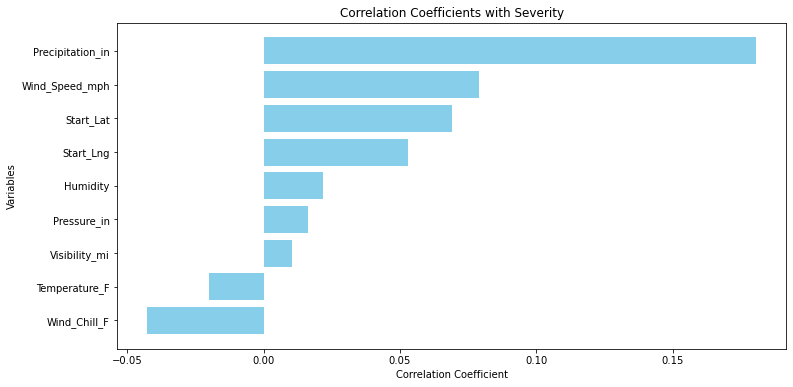

```python
# Get the numeric columns

def get_numceric_columns(df):
    numeric_cols = [col for col in df.columns if col != "Severity" and isinstance(df.schema[col].dataType, FloatType)]
    return numeric_cols

numeric_cols = get_numceric_columns(df)

# Calculate correlation coefficients
correlations = [df.stat.corr(col, 'Severity') for col in numeric_cols]

# Create a DataFrame with column labels and correlation values
corr_df = spark.createDataFrame(zip(numeric_cols, correlations), ['Variable', 'Correlation'])
corr_df = corr_df.orderBy('Correlation')

# Convert the DataFrame to Pandas for plotting
corr_pd = corr_df.toPandas()

# Plot the correlation coefficients
plt.figure(figsize=(12, 6))
plt.barh(corr_pd['Variable'], corr_pd['Correlation'], color='skyblue')
plt.xlabel("Correlation Coefficient")
plt.ylabel("Variables")
plt.title("Correlation Coefficients with Severity")
plt.show()
```

#### Correlation between Severity and Bool Variables (Bar Chart)

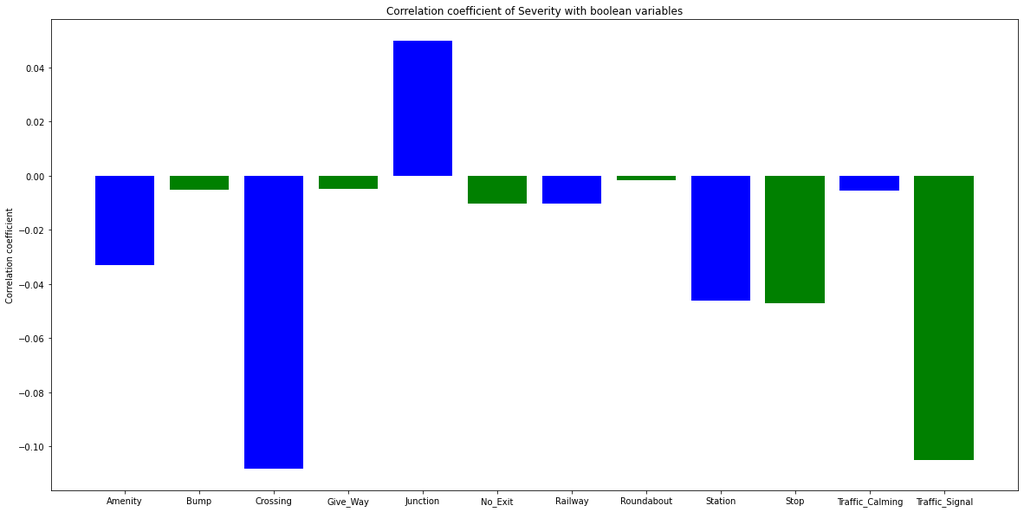

```python
# Assign column names to `columns`
columns = ['Amenity', 'Bump', 'Crossing', 'Give_Way', 'Junction', 'No_Exit', 'Railway', 'Roundabout', 'Station', 'Stop', 'Traffic_Calming', 'Traffic_Signal']

# Convert the DataFrame columns to boolean type
df = convertColumn(df, columns, BooleanType())

# Convert boolean columns to numerical (0 or 1) using `when` function
df_numeric = df.select(['Severity'] + [when(col(c), True).otherwise(False).cast("integer").alias(c) for c in columns])

labels = []
corr_values = []
for col in columns:
    labels.append(col)
    corr_values.append(df_numeric.stat.corr(col, 'Severity'))

ind = range(len(labels))
fig, ax = plt.subplots(figsize=(20, 10))
rects = ax.bar(ind, corr_values, color=['b', 'g'])
ax.set_xticks(ind)
ax.set_xticklabels(labels)
ax.set_ylabel("Correlation coefficient")
ax.set_title("Correlation coefficient of Severity with boolean variables")
plt.show()
```

#### Map showing where the accidents occurred, the colour indicates the severity

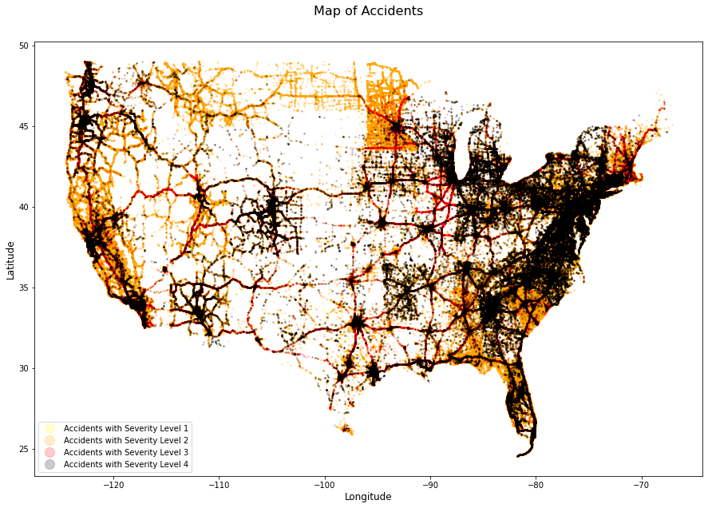

```python
# Filter the DataFrame based on Severity level 4
df_1 = df.filter(df['Severity'] == 1)
df_2 = df.filter(df['Severity'] == 2)
df_3 = df.filter(df['Severity'] == 3)
df_4 = df.filter(df['Severity'] == 4)

# Convert the relevant columns to Pandas Series
longitude_1 = df_1.select('Start_Lng').toPandas()['Start_Lng']
latitude_1 = df_1.select('Start_Lat').toPandas()['Start_Lat']
longitude_2 = df_2.select('Start_Lng').toPandas()['Start_Lng']
latitude_2 = df_2.select('Start_Lat').toPandas()['Start_Lat']
longitude_3 = df_3.select('Start_Lng').toPandas()['Start_Lng']
latitude_3 = df_3.select('Start_Lat').toPandas()['Start_Lat']
longitude_4 = df_4.select('Start_Lng').toPandas()['Start_Lng']
latitude_4 = df_4.select('Start_Lat').toPandas()['Start_Lat']

plt.figure(figsize=(15, 10))

plt.plot(longitude_1, latitude_1, linestyle='', marker='o', markersize=1.5, color="yellow", alpha=0.2, label='Accidents with Severity Level 1')
plt.plot(longitude_2, latitude_2, linestyle='', marker='o', markersize=1.5, color="orange", alpha=0.2, label='Accidents with Severity Level 2')
plt.plot(longitude_3, latitude_3, linestyle='', marker='o', markersize=1.5, color="red", alpha=0.2, label='Accidents with Severity Level 3')
plt.plot(longitude_4, latitude_4, linestyle='', marker='o', markersize=1.5, color="black", alpha=0.2, label='Accidents with Severity Level 4')
plt.legend(markerscale=8)
plt.xlabel('Longitude', size=12, labelpad=3)
plt.ylabel('Latitude', size=12, labelpad=3)
plt.title('Map of Accidents', size=16, y=1.05)
plt.show()
```